# SL Final Project: IMDB Movie Reviews

Jake Greenberg - `jgreenberg5342@floridapoly.edu`

Wyatt Smith - `wsmith4725@floridapoly.edu`

# Preparation

## Libraries loaded

```r
library(tidyverse)
library(caret)
library(glmnet)
```

## Data set Importation

```r
IMDB <- read_csv("https://raw.githubusercontent.com/wsmith867/SL_Project/master/IMDB_movies.csv")
```

# Introduction

The medium of Movies has come a long way over the years from when the first motion pictures were introduced. From the advancements in technology, whether it is CGI or Practical Effects, to how stories are developed and told, Movies has become one of the most easily recognizable and thought of medium for art and story telling. Every time a new trailer for a movie comes out, it jumps to #1 trending on social media or Youtube, with millions of people seeing and reacting to these up coming movies. Movies have become so popular in fact that not only do they cost millions to make, but also make millions on ticket sales. Sometimes, depending on the movie, entire theaters sell out seats on opening day and maybe even the following day. It comes to no surprise that when studios are making a movie, that they would want to turn a profit from the amount of money being spent on creating the movie.

A good point of reference on knowing how well a movie will do is the reviews it has received. This will be the main goal of this report, to find variables that could potentially predict a movie’s rating. Given the nature of movies, some variables already seem like most obvious predictors in a movie’s rating. These being `Actors`, as that is a main advertisement with movies, the `Director` of the movie, and the `Genre` of the movie. Other variables such as `Revenue` will most likely be excluded, since while this variable can infer how well a movie did financially, it may not be a factor towards its ratings. `Rank` will also be excluded as this is essentially an ID type of variable.

# Exploratory Data Analysis

## Data Preparation

| Variable | Description |
| --- | --- |
| `Rank` | IMDB Ranking |
| `Title` | Title Name |
| `Genre` | Category of Movie |
| `Description` | Plot Description |
| `Director` | Director Name |
| `Actors` | Actor Names |
| `Year` | Year Released |
| `Runtime (Minutes)` | Duration in minutes |
| `Rating` | IMDB Rating (Out of 10) |
| `Votes` | Number of votes received |
| `Revenue (Millions)` | Total Movie Sales |
| `Metascore` | Metascore Rating (Out of 100) |

*Table of variables and their description*

As we can see in the above table, this data set has two different rating scores, one being out of 10, the other being out of 100. For the purpose of simplicity, we will convert the IMDB rating to be out of 100 by multiplying the values by 10. With that we will then take the average of the rating from IMDB and the rating from Metacritic to have one rating variable for each movie.

```r
IMDB <- IMDB %>%
  mutate(Rating = Rating * 10) %>%
  mutate(Ave_Rating = (Rating+Metascore)/2)
head(IMDB)
```

| Rank | Title | Genre | Description | Director | Actors | Year | Runtime (Minutes) | Rating | Votes | Revenue (Millions) | Metascore | Ave_Rating |
| --- | --- | --- | --- | --- | --- | --- | --- | --- | --- | --- | --- | --- |
| 1 | Guardians of the Galaxy | Action,Adventure,Sci-Fi | A group of intergalactic criminals are forced to work together to stop a fanatical warrior from taking control of the universe. | James Gunn | Chris Pratt, Vin Diesel, Bradley Cooper, Zoe Saldana | 2014 | 121 | 81 | 757074 | 333.13 | 76 | 78.5 |
| 2 | Prometheus | Adventure,Mystery,Sci-Fi | Following clues to the origin of mankind, a team finds a structure on a distant moon, but they soon realize they are not alone. | Ridley Scott | Noomi Rapace, Logan Marshall-Green, Michael Fassbender, Charlize Theron | 2012 | 124 | 70 | 485820 | 126.46 | 65 | 67.5 |
| 3 | Split | Horror,Thriller | Three girls are kidnapped by a man with a diagnosed 23 distinct personalities. They must try to escape before the apparent emergence of a frightful new 24th. | M. Night Shyamalan | James McAvoy, Anya Taylor-Joy, Haley Lu Richardson, Jessica Sula | 2016 | 117 | 73 | 157606 | 138.12 | 62 | 67.5 |
| 4 | Sing | Animation,Comedy,Family | In a city of humanoid animals, a hustling theater impresario's attempt to save his theater with a singing competition becomes grander than he anticipates even as its finalists' find that their lives w… | Christophe Lourdelet | Matthew McConaughey,Reese Witherspoon, Seth MacFarlane, Scarlett Johansson | 2016 | 108 | 72 | 60545 | 270.32 | 59 | 65.5 |
| 5 | Suicide Squad | Action,Adventure,Fantasy | A secret government agency recruits some of the most dangerous incarcerated super-villains to form a defensive task force. Their first mission: save the world from the apocalypse. | David Ayer | Will Smith, Jared Leto, Margot Robbie, Viola Davis | 2016 | 123 | 62 | 393727 | 325.02 | 40 | 51.0 |
| 6 | The Great Wall | Action,Adventure,Fantasy | European mercenaries searching for black powder become embroiled in the defense of the Great Wall of China against a horde of monstrous creatures. | Yimou Zhang | Matt Damon, Tian Jing, Willem Dafoe, Andy Lau | 2016 | 103 | 61 | 56036 | 45.13 | 42 | 51.5 |

We will now remove the variables that will not be included in our models.

```r
IMDB_data <- IMDB %>%
  select(Title, Genre, Director, Actors, Votes, `Runtime (Minutes)`, Ave_Rating)
```

```r
IMDB_data <- IMDB_data %>%
  mutate(Title = as.factor(Title),
         Genre = as.factor(Genre),
         Director = as.factor(Director),
         Actors = as.factor(Actors))
```

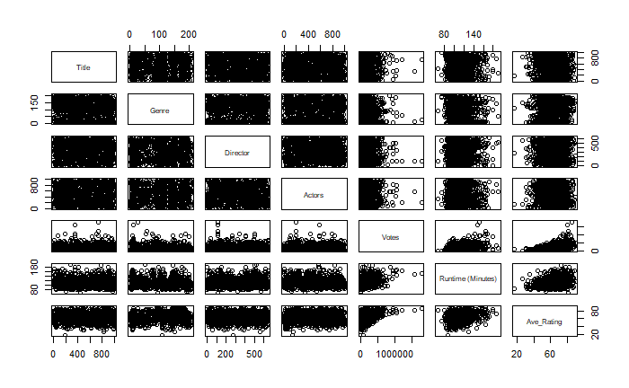

```r
pairs(IMDB_data)
```